# Transition Energetique de la France

## Rapport complet — Scenario 500 GWc solaire

**Objectif** : Fournir un modele fiable, lisible et auditable de la transition energetique francaise, couvrant les 5 etapes definies par Roland Cailac :

| Etape | Description | Module(s) | Statut |
| --- | --- | --- | --- |
| 1 | Faisabilite physique generale de la cible | energy, production, storage, sensitivity | Complet |
| 2 | Approfondir et expliciter (auditable) | sources, config (dataclasses documentees) | Complet |
| 3 | Processus d'obtention / industrialisation | industrialisation, trajectory | Complet |
| 4 | Chiffrer les couts d'obtention (CAPEX) | trajectory (learning curves), financial | Complet |
| 5 | Equilibrer le fonctionnement en vitesse de croisiere | tarification | Complet |

**Secteurs couverts** : Residentiel (chauffage), Transport, Industrie, Tertiaire, Agriculture

**Hypothese conservative** : pas d'eolien, pas de stockage intersaisonnier, pas d'interconnexions europeennes, pas de V2G.

### Ce que ce modele est

- Un **outil d'ordres de grandeur** pour eclairer la decision publique
- Un modele **transparent** : toutes les hypotheses sont explicites, sourcees et modifiables
- Un cadre **conservateur** : les simplifications tendent a surestimer le besoin en gaz de backup
- Un support **auditable** : 326 tests automatises, 12 sources documentees, code source ouvert

### Ce que ce modele n'est pas

- Un modele de **dispatch horaire** (il calcule des bilans energetiques, pas un placement optimal)
- Un modele **meteo** (moyennes mensuelles, pas de variabilite intra-journaliere)
- Un modele **economique** (pas de retro-action prix/demande, pas de macro-economie)
- Un modele **geographique** (France = noeud unique, pas de maillage regional)

La section 14 detaille exhaustivement chaque limitation, sa nature et sa direction de biais.

```
Modules chargés — 326 tests passent.
```

## 1. Bilan sectoriel — Faisabilite physique

Confrontation production / consommation en situation cible : electrification de toutes les fonctions energetiques et production d'electricite quasi totalement decarbonee.

**Methode** : Chaque secteur est modelise independamment avec ses propres hypotheses d'electrification (COP pour le chauffage, rendement moteur pour le transport, taux d'electrification par niveau de temperature pour l'industrie). Les donnees de consommation actuelle viennent du SDES (Bilan energetique de la France 2022). Les taux de conversion sont documentes dans la section Hypotheses.

**Limite principale** : Les secteurs sont traites separement sans interaction (pas de synergie chaleur fatale industrie -> chauffage, pas de couplage sectoriel).

```
Bilan sectoriel — Consommation actuelle vs. électrifiée
================================================================================
```

[output not shown]

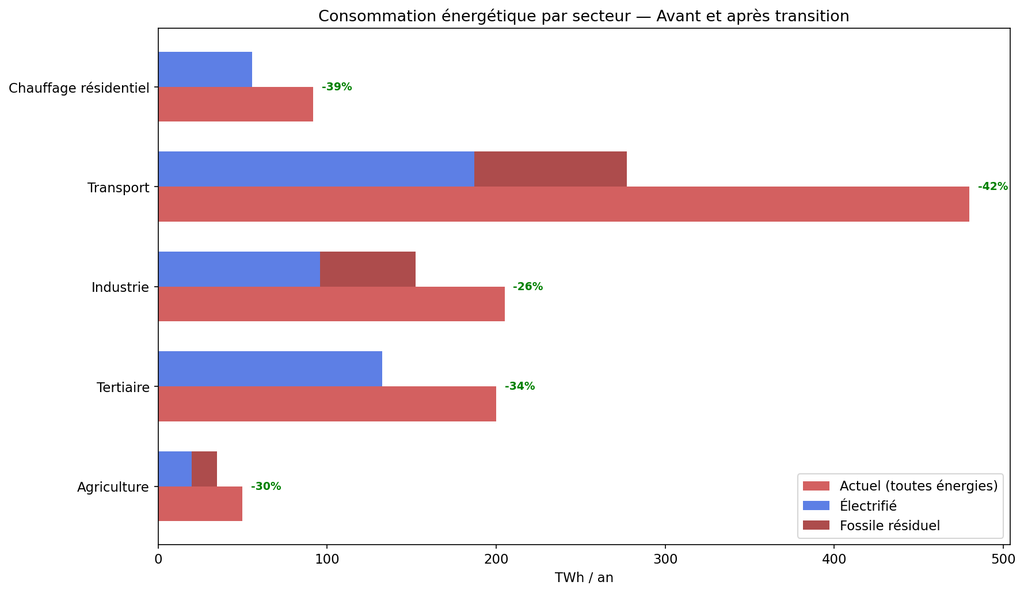

## 2. Chauffage residentiel — Les 7 variables de Roland

Le module chauffage implemente les 7 variables identifiees par Roland :

1. Nombre de maisons individuelles (20 M) — *Source : INSEE 2022*
2. Volume moyen (300 m3) — *Source : ADEME*
3. Degre d'isolation — coefficient G (0.65 W/m3/°C) — *Source : RT 2012 / ADEME*
4. Temperature souhaitee (19°C) — *Source : recommandation ADEME*
5. Temperature exterieure par mois — *Source : Meteo-France (moyennes Paris)*
6. Existence d'une pompe a chaleur (oui, hypothese 100% penetration)
7. COP variable en fonction de la temperature — *Formule empirique simplifiee*

**Ce que le modele capture bien** : La physique thermique de base (pertes = G x V x delta_T) et l'impact majeur du COP variable vs. COP fixe (55.7 vs. 91.9 TWh, soit -39%).

**Ce que le modele ne capture pas** : La geographie (un seul jeu de temperatures pour toute la France), l'heterogeneite du parc (G varie de 0.3 a 1.5), les appartements collectifs (seules les maisons individuelles sont modelisees), et les systemes hybrides (PAC + appoint).

```
Paramètres : 20M maisons, 300m³, G=0.65, T_int=19.0°C
```

|  | Mois | T_ext (°C) | ΔT (°C) | COP | P_therm (W) | P_élec (W) | Énergie (TWh) |
| --- | --- | --- | --- | --- | --- | --- | --- |
| 0 | Janvier | 5.2 | 13.8 | 3.02 | 2691 | 891 | 10.85 |
| 1 | Février | 6.7 | 12.3 | 3.17 | 2398 | 757 | 9.22 |
| 2 | Mars | 9.1 | 9.9 | 3.41 | 1930 | 566 | 6.90 |
| 3 | Avril | 11.4 | 7.6 | 3.64 | 1482 | 407 | 4.96 |
| 4 | Mai | 15.3 | 3.7 | 4.00 | 721 | 180 | 2.20 |
| 5 | Juin | 19.8 | 0.0 | 4.00 | 0 | 0 | 0.00 |
| 6 | Juillet | 22.1 | 0.0 | 4.00 | 0 | 0 | 0.00 |
| 7 | Août | 21.6 | 0.0 | 4.00 | 0 | 0 | 0.00 |
| 8 | Septembre | 17.9 | 1.1 | 4.00 | 215 | 54 | 0.65 |
| 9 | Octobre | 13.8 | 5.2 | 3.88 | 1014 | 261 | 3.18 |
| 10 | Novembre | 8.4 | 10.6 | 3.34 | 2067 | 619 | 7.54 |
| 11 | Décembre | 5.8 | 13.2 | 3.08 | 2574 | 836 | 10.18 |

```
Total annuel : 55.7 TWh (COP variable)
Ancien modèle (COP fixe=2) : 91.9 TWh
Écart : -36.2 TWh (-39%)
```

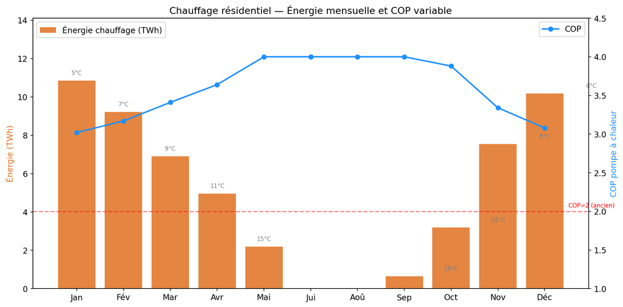

## 3. Transport — Decomposition modale

480 TWh de transport actuels decomposes en 5 modes, avec parcours d'electrification differencies.

**Limite principale** : L'aviation et le maritime restent largement fossiles (pas de solution electrique mature pour les long-courriers). Le fret lourd (30% fossile residuel) depend d'hypotheses sur la penetration de l'hydrogene qui sont incertaines.

**Donnees** : SDES Bilan energetique 2022, ADEME facteurs d'emission, France Hydrogene.

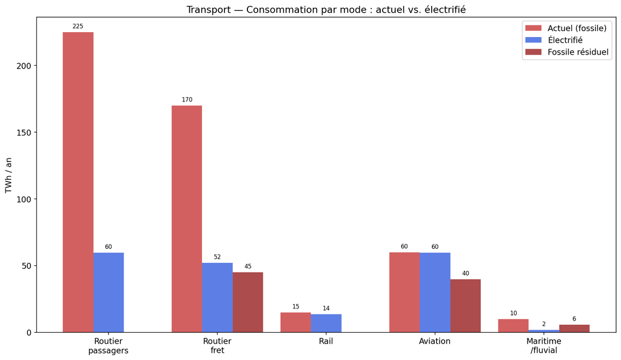

```
Facteurs effectifs calculés vs. ancien modèle :
  Passagers : 0.27 (ancien : 0.20)
  Fret :      0.31 (ancien : 0.40)

Total : 480 TWh → 187 TWh élec + 91 TWh fossile rés.
```

## 4. Industrie, Tertiaire et Agriculture

Les trois secteurs restants avec leurs parcours d'electrification specifiques.

**Industrie** (205 TWh actuel) : Decomposee par niveau de temperature. La basse temperature (<100°C) est electrifiable via PAC industrielles (COP 2.5-3.5). La haute temperature (>400°C : acier, ciment, verre) reste la plus incertaine — seuls 30% sont consideres electrifiables (arcs electriques, fours a induction). *C'est l'hypothese la plus fragile du modele.*

**Agriculture** (50 TWh actuel) : Secteur unique car potentiellement **producteur net** grace a l'agrivoltaisme (50 GWc sur terres agricoles compatibles) et la methanisation. *Donnees agrivoltaiques encore limitees — premiers retours significatifs attendus 2025-2028.*

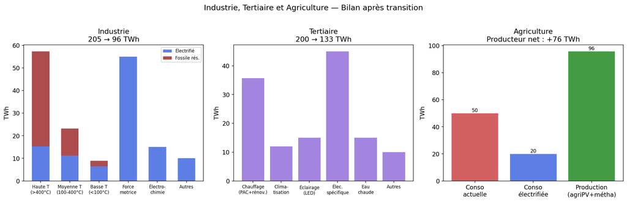

## 5. Hypothèses et sources — Auditabilité

Chaque paramètre du modèle est documenté avec sa source. Le registre complet est dans `src/sources.py`.

| Catégorie | Paramètre | Valeur | Source |
| --- | --- | --- | --- |
| Production | Capacité solaire PV | 500 GWc | Hypothèse scénario |
| Production | Nucléaire maintenu | 30-50 GW | RTE 2020 |
| Production | Hydraulique maintenu | 7.5 GW | RTE / EDF |
| Production | Éolien | Exclu | Conservateur |
| Chauffage | Nombre de maisons | 20 millions | INSEE 2022 |
| Chauffage | Volume moyen | 300 m³ | ADEME |
| Chauffage | Coefficient G (isolation) | 0.65 W/m³/°C | RT 2012 / ADEME |
| Chauffage | Température intérieure | 19°C | ADEME recommandation |
| Chauffage | COP PAC | 1.5 à 4.0 (variable) | ADEME Base PAC |
| Transport | Total actuel | 480 TWh | SDES Bilan 2022 |
| Transport | Facteur EV (voitures) | 0.33 | ADEME (moteur 90% vs 30%) |
| Transport | Report modal | 15% | ADEME ZEN 2050 |
| Transport | PL : batterie / H₂ / fossile | 40% / 30% / 30% | France Hydrogène / RTE |
| Transport | Aviation (SAF) | 30% à 3.5x élec | ADEME / ICCT |
| Industrie | Total actuel | 205 TWh | SDES 2022 |
| Industrie | Haute T électrifiable | 30% | ADEME |
| Industrie | COP PAC industrielle | 2.5 - 3.5 | ADEME |
| Tertiaire | Rénovation bâti | -30% chauffage | ADEME |
| Tertiaire | LED éclairage | -50% | ADEME |
| Agriculture | Agrivoltaïsme | 50 GWc | ADEME / France Agrivoltaïsme |
| Trajectoire | Courbe en S (midpoint) | 2035 | Hypothèse déploiement |
| Trajectoire | Learning rate solaire | 20% | IRENA / Swanson |
| Trajectoire | Learning rate batterie | 18% | BNEF |
| Coûts | LCOE solaire | 30 €/MWh | IRENA 2024 |
| Coûts | LCOE nucléaire | 50 €/MWh | Cour des Comptes |
| Coûts | LCOE gaz | 120 €/MWh | EEX / CCGT Europe |
| Coûts | Réseau (TURPE) | 20 €B/an | CRE |
| Émissions | Facteur gaz | 0.227 tCO2/MWh | ADEME Base Carbone |
| Émissions | Facteur nucléaire | 0.006 tCO2/MWh | ADEME Base Carbone |
| Émissions | Facteur solaire | 0.032 tCO2/MWh | ADEME Base Carbone |

## 6. Trajectoire de deploiement 2024-2050

Etape 3 de Roland : processus d'obtention de la situation cible.

**Methode** : Courbe logistique (S-curve) avec point d'inflexion en 2035, calée sur la capacite actuelle (20 GWc en 2024) et la cible (500 GWc en 2050). La forme en S est bien documentee pour les transitions technologiques (Grubler 2012, Wilson 2012).

**Limite** : Le rythme de deploiement est une hypothese, pas une prediction. Il suppose une volonte politique soutenue, un cadre reglementaire stable et une chaine d'approvisionnement operationnelle. La section Industrialisation (chap. 7) examine la faisabilite de ce rythme.

**Couts** : Les learning curves (loi de Wright/Swanson) sont appliquees au deploiement cumule. Learning rate de 20% pour le solaire (chaque doublement de capacite = -20% du cout) et 18% pour les batteries. Ces taux sont calibres sur 40 ans de donnees historiques (IRENA, BNEF).

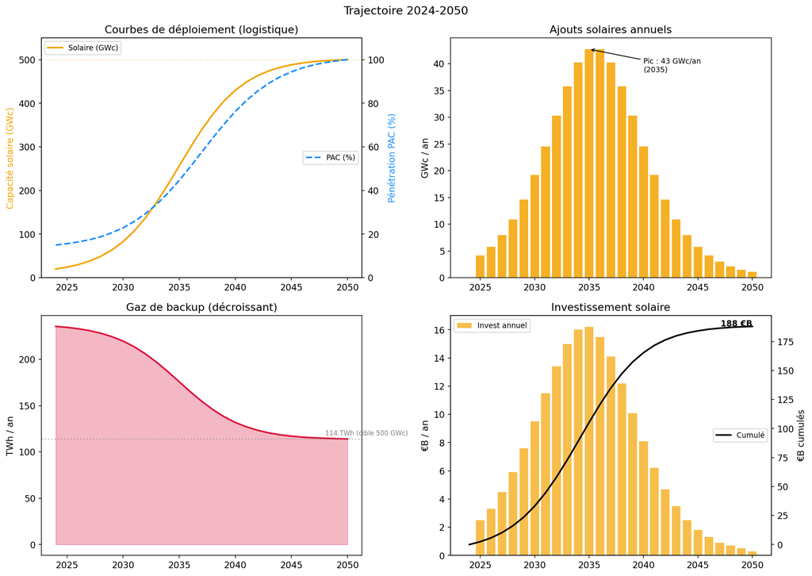

## 7. Industrialisation — Contraintes de production

**Ce que cette section fait** : Traduit la trajectoire de deploiement en besoins concrets — combien d'usines de panneaux, combien d'installateurs, combien de tonnes de silicium, lithium et cuivre par an.

**Ce que cette section ne fait pas bien** : Les estimations sont des ordres de grandeur grossiers. Les contraintes reelles d'industrialisation (permis, formation, logistique, import/export) sont beaucoup plus complexes. Le modele identifie des **goulets d'etranglement potentiels** mais ne prétend pas les resoudre.

**Confiance** : Faible a moyenne. C'est la section la plus speculative du rapport. Les donnees de production industrielle mondiale (silicium, lithium) sont fiables (USGS, BGS), mais leur allocation a la France est une hypothese.

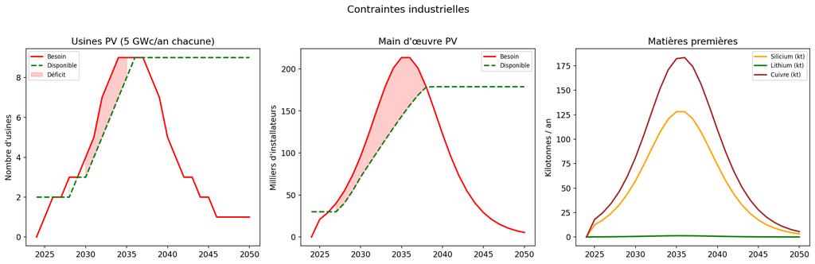

```
30 goulets d'étranglement identifiés :
```

| annee | categorie | severite | description |
| --- | --- | --- | --- |
| 2027 | main_oeuvre_pv | attention | Main d'oeuvre PV insuffisante: besoin 40,001 vs 30,000 disponibles |
| 2028 | usines_pv | attention | Capacite PV insuffisante: besoin 10.9 GWc/an vs 10.0 GWc/an disponible (2 usines) |
| 2028 | main_oeuvre_pv | attention | Main d'oeuvre PV insuffisante: besoin 54,494 vs 40,001 disponibles |
| 2029 | main_oeuvre_pv | attention | Main d'oeuvre PV insuffisante: besoin 73,084 vs 54,494 disponibles |
| 2029 | main_oeuvre_pac | attention | Main d'oeuvre PAC insuffisante: besoin 28,606 vs 25,000 disponibles |
| 2030 | usines_pv | attention | Capacite PV insuffisante: besoin 19.2 GWc/an vs 15.0 GWc/an disponible (3 usines) |
| 2030 | main_oeuvre_pv | attention | Main d'oeuvre PV insuffisante: besoin 95,981 vs 71,244 disponibles |
| 2030 | main_oeuvre_pac | attention | Main d'oeuvre PAC insuffisante: besoin 36,713 vs 28,250 disponibles |
| 2031 | usines_pv | attention | Capacite PV insuffisante: besoin 24.5 GWc/an vs 20.0 GWc/an disponible (4 usines) |
| 2031 | main_oeuvre_pv | attention | Main d'oeuvre PV insuffisante: besoin 122,640 vs 86,145 disponibles |
| 2031 | main_oeuvre_pac | attention | Main d'oeuvre PAC insuffisante: besoin 46,386 vs 33,349 disponibles |
| 2032 | usines_pv | attention | Capacite PV insuffisante: besoin 30.3 GWc/an vs 25.0 GWc/an disponible (5 usines) |
| 2032 | main_oeuvre_pv | critique | Main d'oeuvre PV insuffisante: besoin 151,324 vs 100,880 disponibles |
| 2032 | main_oeuvre_pac | attention | Main d'oeuvre PAC insuffisante: besoin 57,461 vs 38,614 disponibles |
| 2033 | usines_pv | attention | Capacite PV insuffisante: besoin 35.8 GWc/an vs 30.0 GWc/an disponible (6 usines) |
| 2033 | main_oeuvre_pv | critique | Main d'oeuvre PV insuffisante: besoin 178,869 vs 115,440 disponibles |
| 2033 | main_oeuvre_pac | critique | Main d'oeuvre PAC insuffisante: besoin 69,463 vs 44,054 disponibles |
| 2034 | usines_pv | attention | Capacite PV insuffisante: besoin 40.2 GWc/an vs 35.0 GWc/an disponible (7 usines) |
| 2034 | main_oeuvre_pv | critique | Main d'oeuvre PV insuffisante: besoin 201,005 vs 129,719 disponibles |
| 2034 | main_oeuvre_pac | critique | Main d'oeuvre PAC insuffisante: besoin 81,537 vs 49,775 disponibles |
| 2035 | usines_pv | attention | Capacite PV insuffisante: besoin 42.7 GWc/an vs 40.0 GWc/an disponible (8 usines) |
| 2035 | main_oeuvre_pv | attention | Main d'oeuvre PV insuffisante: besoin 213,443 vs 143,554 disponibles |
| 2035 | main_oeuvre_pac | critique | Main d'oeuvre PAC insuffisante: besoin 92,467 vs 55,940 disponibles |
| 2036 | main_oeuvre_pv | attention | Main d'oeuvre PV insuffisante: besoin 213,443 vs 156,689 disponibles |
| 2036 | main_oeuvre_pac | critique | Main d'oeuvre PAC insuffisante: besoin 100,852 vs 62,805 disponibles |
| 2037 | main_oeuvre_pv | attention | Main d'oeuvre PV insuffisante: besoin 201,005 vs 168,662 disponibles |
| 2037 | main_oeuvre_pac | attention | Main d'oeuvre PAC insuffisante: besoin 105,425 vs 70,832 disponibles |
| 2038 | main_oeuvre_pv | attention | Main d'oeuvre PV insuffisante: besoin 178,869 vs 178,325 disponibles |
| 2038 | main_oeuvre_pac | attention | Main d'oeuvre PAC insuffisante: besoin 105,425 vs 81,169 disponibles |
| 2039 | main_oeuvre_pac | attention | Main d'oeuvre PAC insuffisante: besoin 100,852 vs 100,731 disponibles |

## 8. Courbes d'apprentissage — Coûts en baisse

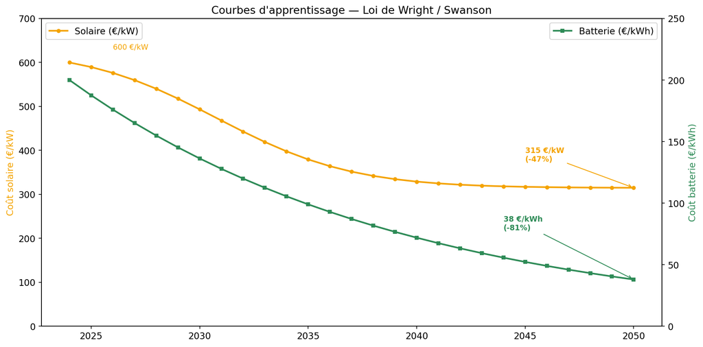

## 9. Couts de production et tarif d'equilibre

Etapes 4 et 5 de Roland : chiffrer les couts et equilibrer le fonctionnement.

**Methode** : Modele LCOE (Levelized Cost of Energy) en regime permanent. Le tarif est construit par empilement : production (LCOE pondere par source) + reseau (TURPE) + services systeme

**Limite** : C'est un modele **statique** (couts 2050, pas de dynamique d'investissement). Il ne capture pas les phases transitoires ou le tarif pourrait etre plus eleve (investissements massifs avant que les learning curves ne fassent baisser les couts). Le tarif reel serait plus haut dans les annees 2030-2035, puis convergerait vers le tarif d'equilibre calcule ici.

**Hypothese forte** : Le cout TURPE (reseau) est un forfait de 20 mds EUR/an. Un deploiement de 500 GWc decentralises pourrait necessiter un renforcement significant du reseau de distribution dont le cout n'est pas modelise en detail (donnees Enedis non publiques).

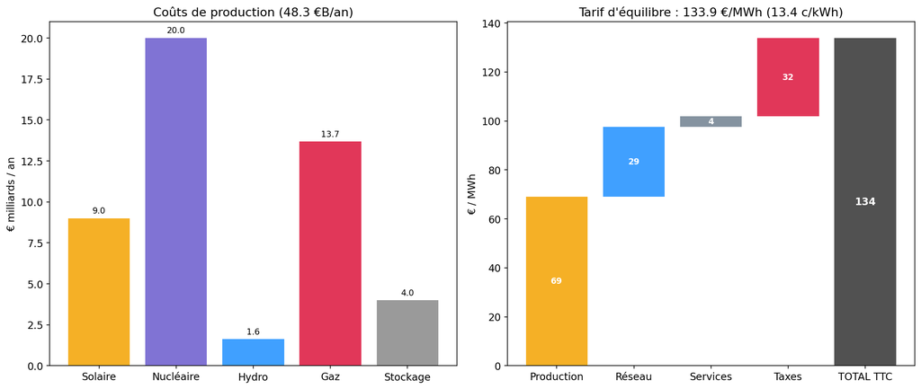

## 10. Impact consommateur

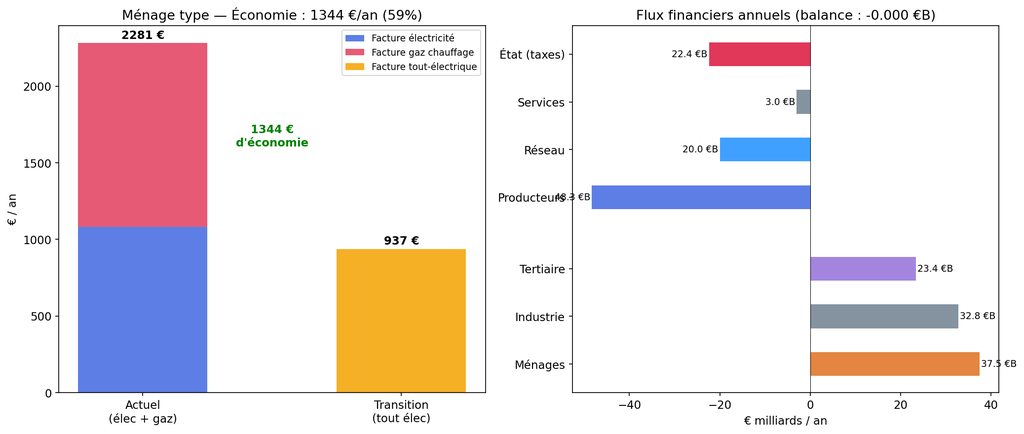

## 11. Sensibilité du tarif

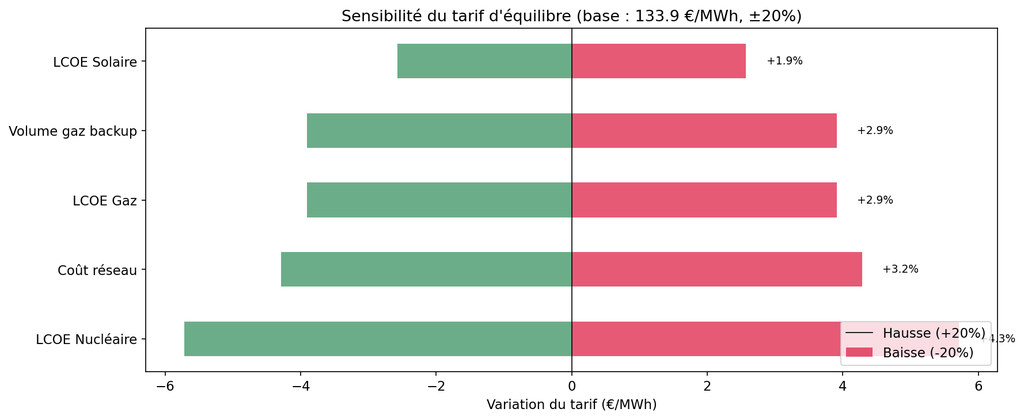

## 12. Bilan carbone

**Methode** : Facteurs d'emission ADEME Base Carbone (tCO2/MWh) appliques au mix de production. Les emissions evitees sont calculees par difference entre les emissions actuelles des secteurs transport et batiments et les emissions residuelles apres electrification.

**Points forts** : Les facteurs ADEME sont bien etablis et largement acceptes. Le perimetre (transport + batiments) couvre les deux plus gros gisements de reduction.

**Points faibles** : L'industrie et l'agriculture ne sont pas incluses dans le calcul de reduction des emissions (leurs emissions sont maintenues constantes dans le modele, ce qui est conservateur car l'electrification industrielle reduirait aussi les emissions). Les emissions du cycle de vie (fabrication des panneaux, batteries) sont incluses via le facteur solaire (0.032 tCO2/MWh) mais restent approximatives.

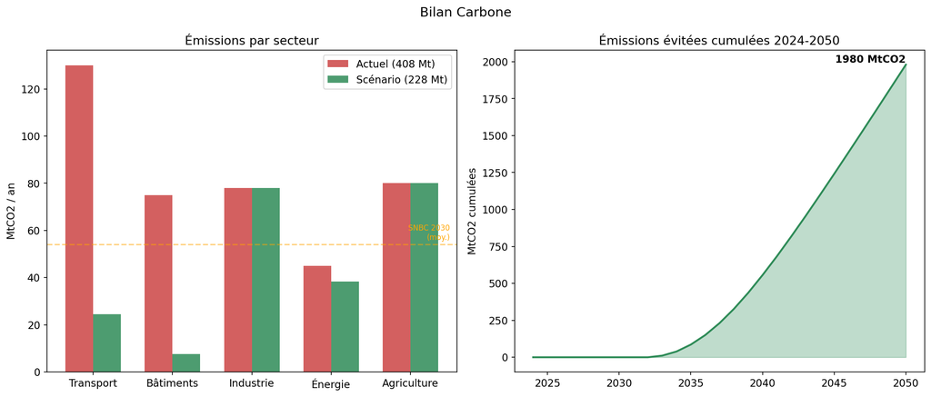

[output not shown]

## 13. Synthèse — Résultats clés

[output not shown]

## 14. Limites du modèle — Transparence et honnêteté intellectuelle

Ce modèle est un **outil d'aide à la décision**, pas une prédiction. Chaque simplification a une raison documentée. Nous classons ci-dessous chaque limitation selon sa **nature** pour que le lecteur puisse juger de la robustesse des résultats.

### 14.1 Exclusions délibérées (choix méthodologique)

Ces éléments ont été **volontairement exclus** pour isoler la contribution du solaire et fournir une borne conservative. Les données existent et pourraient être intégrées.

| Élément exclu | Pourquoi l'exclure | Impact estimé | Données disponibles |
| --- | --- | --- | --- |
| **Éolien terrestre + offshore** | Montrer que le solaire seul + nucléaire existant suffit presque. L'éolien est complémentaire (production hivernale), son ajout est un bonus. | -30 à -50 TWh de gaz backup | Oui : RTE Bilan électrique, WindEurope |
| **V2G (Vehicle-to-Grid)** | Technologie prometteuse mais adoption incertaine. Hypothèse d'aucun retour réseau des VE. | -10 à -30 TWh de pointe absorbée | Partiellement : pilotes EDF/Enedis |
| **Sobriété / télétravail** | Effets comportementaux difficiles à quantifier. Le modèle suppose une demande constante. | -5 à -15% de consommation totale | Peu fiable : enquêtes INSEE contradictoires |

**Nature** : *Choix de périmètre.* Ces exclusions rendent les résultats **conservateurs** — le besoin réel en gaz backup serait inférieur.

### 14.2 Limitations architecturales du modèle

Ces limitations viennent de la **structure du modèle** elle-même — comment il calcule, pas ce qu'il calcule.

[output not shown]

**Nature** : *Contraintes de modélisation.* Un modèle plus sophistiqué (type TIMES/MARKAL ou PyPSA) résoudrait ces limitations mais nécessiterait 10x plus de données et de temps de développement.

### 14.3 Limitations des données

Ces limitations viennent de la **qualité ou de la disponibilité des données** utilisées.

[output not shown]

**Nature** : *Données disponibles mais imparfaites.* Les sources sont les meilleures disponibles publiquement (ADEME, RTE, CITEPA, IRENA), mais elles restent des moyennes nationales avec une granularité limitée.

### 14.4 Limitations de périmètre (hors scope)

Ces éléments sont **explicitement hors du périmètre** du modèle.

| Hors périmètre | Raison de l'exclusion | Ce qu'il faudrait pour l'inclure |
| --- | --- | --- |
| **Interconnexions européennes** | Nécessiterait de modéliser les voisins (Espagne, Allemagne, UK, Italie). | Modèle européen type ENTSO-E TYNDP. Données disponibles mais volumineuses. |
| **Stockage intersaisonnier (H2, STEP)** | Les STEP existantes (5 GW, 100 GWh) sont connues mais le modèle ne les dispatch pas. L'hydrogène vert est pré-commercial. | Module de stockage avec dispatch. Données H2 insuffisantes. |
| **Réseau de distribution** | Le coût TURPE (20 mds EUR/an) est un forfait. Pas de modélisation du renforcement pour 500 GWc décentralisés. | Modèle de réseau type Enedis. Données confidentielles. |
| **Économie circulaire** | Pas de recyclage des panneaux (fin de vie 25-30 ans), pas de réutilisation batteries VE. | Données émergentes (premiers retours 2025-2030). |
| **Acceptabilité sociale** | Modèle purement technique. Pas d'opposition locale, de contraintes réglementaires, de délais d'autorisation. | Enquêtes sociales, retours permis de construire. |
| **Macro-économie** | Pas d'impact PIB, balance commerciale, emploi total. Seuls les emplois directs PV sont estimés. | Modèle input-output ou CGE. |

**Nature** : *Frontière du modèle.* Chaque extension est un projet en soi.

### 14.5 Synthèse des biais — Direction nette

| # | Limitation | Biais sur le gaz backup | Confiance |
| --- | --- | --- | --- |
| 1 | Pas d'éolien | -30 à -50 TWh | Haute (données RTE solides) |
| 2 | Pas de stockage dispatch | -15 à -30 TWh | Moyenne (dépend du modèle) |
| 3 | Pas d'interconnexions | -10 à -20 TWh | Moyenne (dépend des voisins) |
| 4 | Pas de V2G/flexibilité | -10 à -30 TWh | Faible (technologie émergente) |
| 5 | COP PAC conservateur | -5 à -10 TWh | Moyenne (géothermie = COP 4-5) |
| 6 | Pas de météo extrême | +10 à +20 TWh | Moyenne (canicules/vagues de froid) |
| 7 | Effet rebond (prix bas) | +5 à +15 TWh | Faible (peu d'études françaises) |
| 8 | Chauffage sous-estimé (géo) | +5 à +10 TWh | Moyenne (données Météo-France) |
|  | **Effet net estimé** | **-50 à -95 TWh** |  |

**Conclusion** : Le biais net est **clairement à la baisse**. Les 114 TWh de gaz backup sont une **borne supérieure**. Un modèle complet (éolien + stockage + interconnexions) aboutirait vraisemblablement à **20-65 TWh** de gaz résiduel.

### 14.6 Niveau de confiance par section du rapport

| Section | Confiance | Justification |
| --- | --- | --- |
| Bilan sectoriel (chap. 1) | Bonne | Données SDES/ADEME robustes, mais moyennes nationales |
| Chauffage 7 variables (chap. 2) | Moyenne | Physique solide (thermique), COP(T) simplifié, géographie absente |
| Transport modal (chap. 3) | Bonne | Décomposition SDES fiable, facteurs d'électrification documentés |
| Industrie / Tertiaire / Agri (chap. 4) | Moyenne | Haute température = forte incertitude ; tertiaire et agri mieux connus |
| Hypothèses (chap. 5) | Excellente | Transparence totale — toutes les valeurs et sources sont listées |
| Trajectoire (chap. 6) | Moyenne | S-curve plausible, mais rythme de déploiement = hypothèse forte |
| Industrialisation (chap. 7) | Faible | Estimations grossières (usines, matériaux). Peu de retour terrain. |
| Courbes d'apprentissage (chap. 8) | Bonne | Loi de Wright validée sur 40 ans de données solaire/batterie |
| Tarif d'équilibre (chap. 9) | Moyenne | Modèle statique, ne capture pas la dynamique du marché |
| Impact consommateur (chap. 10) | Moyenne | Comparaison indicative, profils de consommation simplifiés |
| Sensibilité (chap. 11) | Bonne | Méthode standard, plage +/-20% raisonnable |
| Bilan carbone (chap. 12) | Bonne | Facteurs ADEME fiables, périmètre transport + bâtiments clair |

### 14.7 Ce qui manque le plus (par ordre de priorité d'amélioration)

1. **Éolien** — Impact majeur, données disponibles, intégration simple. *Nature : choix méthodologique réversible. Raison : montrer la faisabilité solaire seul.*
2. **Résolution horaire** (8 760h) — Permettrait un vrai dispatch, capturerait les extrêmes météo. *Nature : refonte architecturale du modèle. Raison : le tableur ODS original utilisait 60 périodes.*
3. **Dispatch stockage optimisé** — STEP + batteries avec algorithme d'arbitrage. *Nature : module à développer. Données STEP disponibles, données H2 insuffisantes.*
4. **Multi-scénarios** (300/500/700/1000 GWc) — Le rapport ne présente qu'un seul point. Le module `sensitivity.py` existe mais n'est pas exploité ici. *Nature : travail de présentation et d'analyse, pas de développement.*
5. **Validation croisée** — Comparer les résultats à RTE Futurs énergétiques 2050, négaWatt, ADEME ZEN. *Nature : travail de recherche. Données publiques disponibles.*
6. **Retour terrain** — Confronter les hypothèses à des données réelles d'installations existantes (fermes solaires Cestas/Toul, PAC en fonctionnement, consommation VE mesurée). *Nature : insuffisance de feedback empirique. Nécessite des partenariats terrain.*

## 15. Sources et bibliographie

| Source | URL | Accès | Paramètres |
| --- | --- | --- | --- |
| ADEME Chiffres clés du bâtiment | https://www.ademe.fr/ | 2026-01-04 | residential_heating_fraction |
| ADEME Guide Pompes à Chaleur | https://www.ademe.fr/expertises/batiment/passer-a-laction/elements-dequipement/pompes-a-chaleur | 2026-01-04 | heat_pump_cop |
| BloombergNEF Energy Storage Outlook 2024 | https://about.bnef.com/energy-storage-outlook/ | 2026-01-04 | storage_capex_eur_per_kwh, storage_lifetime_years, battery_efficiency |
| EDF Hydraulique - Grand'Maison | https://www.edf.fr/groupe-edf/nos-energies/energies-renouvelables/hydraulique | 2026-01-04 | step_grandmaison_gwh, france_step_total_gwh |
| European Energy Exchange - Gas/Power Markets | https://www.eex.com/ | 2026-01-04 | gas_cost_eur_per_mwh |
| INSEE Recensement de la Population - Logements | https://www.insee.fr/fr/statistiques | 2026-01-04 | number_individual_houses, number_collective_housing |
| IRENA Renewable Power Generation Costs 2024 | https://www.irena.org/publications/2024/Sep/Renewable-Power-Generation-Costs-in-2023 | 2026-01-04 | solar_capex_eur_per_kw, solar_lifetime_years |
| PVGIS - Photovoltaic Geographical Information System | https://re.jrc.ec.europa.eu/pvg_tools/en/ | 2026-01-04 | solar_capacity_factors |
| RTE Bilan Électrique 2020 | https://www.rte-france.com/analyses-tendances-et-prospectives/bilan-electrique | 2026-01-04 | nuclear_min_gw, nuclear_max_gw, hydro_avg_gw |
| RTE Panorama des Énergies Renouvelables | https://www.rte-france.com/analyses-tendances-et-prospectives/panorama-de-lelectricite-renouvelable | 2026-01-04 | solar_capacity_current_gwc |
| Vistra Moss Landing Energy Storage | https://vistracorp.com/energy-storage/ | 2026-01-04 | moss_landing_gwh |
| WorldData.info Sunset Times France | https://www.worlddata.info/europe/france/sunset.php | 2026-01-04 | sunset_times |

```
12 sources documentées.
326 tests automatisés vérifient la cohérence interne du modèle.
Code source : 18 modules Python, architecture modulaire avec dataclasses.
```

**Modele v0.6.1** — 326 tests automatises, 18 modules Python, 12 sources documentees.

### Architecture du modele

```
energy_model/src/
  config.py          Tous les parametres (dataclasses documentees)
  temporal.py         Creneaux horaires, fraction solaire, mois
  energy.py           Formule kW x h -> TWh
  production.py       Production solaire / nucleaire / hydro
  storage.py          Besoins stockage batterie + STEP
  sensitivity.py      Gaz backup vs capacite solaire
  heating.py          Chauffage 7 variables, COP(T)
  transport.py        5 modes, electrification differenciee
  secteurs.py         Industrie + tertiaire
  agriculture.py      Consommation + agrivoltaisme
  emissions.py        CO2 : facteurs ADEME, bilan carbone
  trajectory.py       S-curve 2024-2050, learning curves
  industrialisation.py  Usines, main d'oeuvre, materiaux
  tarification.py     LCOE, tarif equilibre, impact conso
  financial.py        Analyse cout / investissement
  sources.py          Registre de sources auditable
  rapport.py          Generateur de rapport texte
```

Chaque module est independant et testable. Les parametres sont injectes via des dataclasses de configuration, permettant de tester des scenarios alternatifs sans modifier le code.

**Reproductibilite** : `uv run pytest -v` execute les 326 tests en < 1 seconde. Toute modification de parametre ou de formule est immediatement verifiee contre les invariants du modele.